# Big Data & Analytics Group Assignment - From quantitative to quality

# Introduction

The dataset we will use for this exercise is a set of speed dating data gathered by Raymond Fisman, et al. (2006) from 8378 students at Columbia University. The data includes:  
- characteristics most important to them for a future date,  
- Score of each person they speed dated and finally give a yes or a no to seeing the other person again on a regular date.

We addressed the following questions:  
• Question 1: What do men and women look for in a date?  
• Question 2: How much do you enjoy your date depending on your initial preferences and actual race of the speed dating partner  
• Question 3: How much do you enjoy your date depending on if your date is the same race as you?  
• Question 4: How much do you enjoy your date depending on your race and race of the speed dating partner

### Investigating the data

We then plotted a histogram to show the age of the participants in the speed dating experiment:

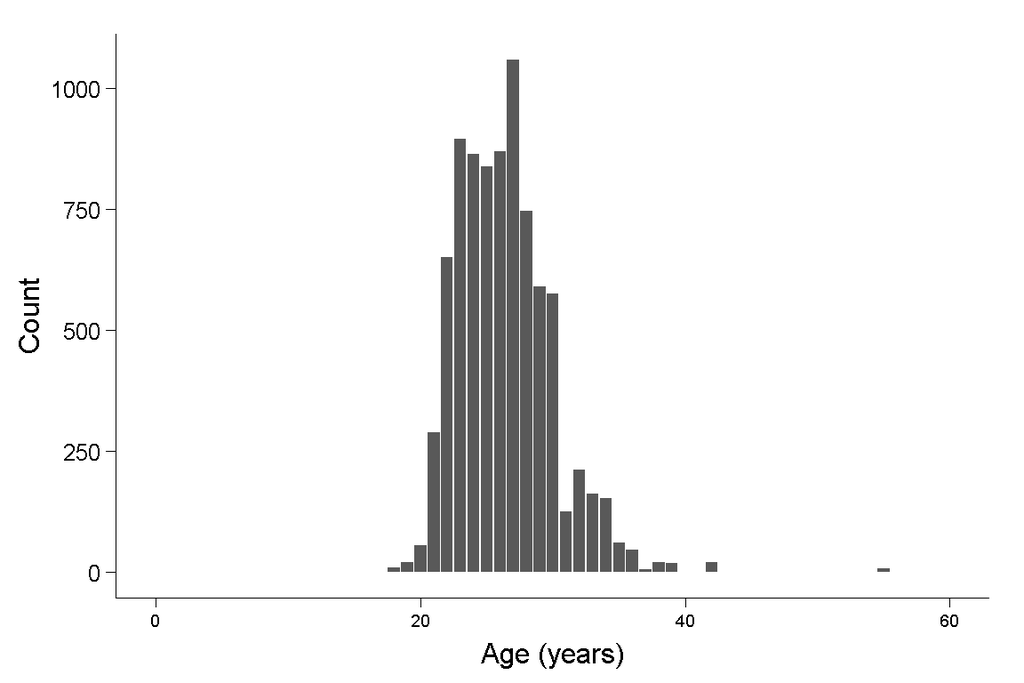

### Question 1: What do men and women look for in a date?

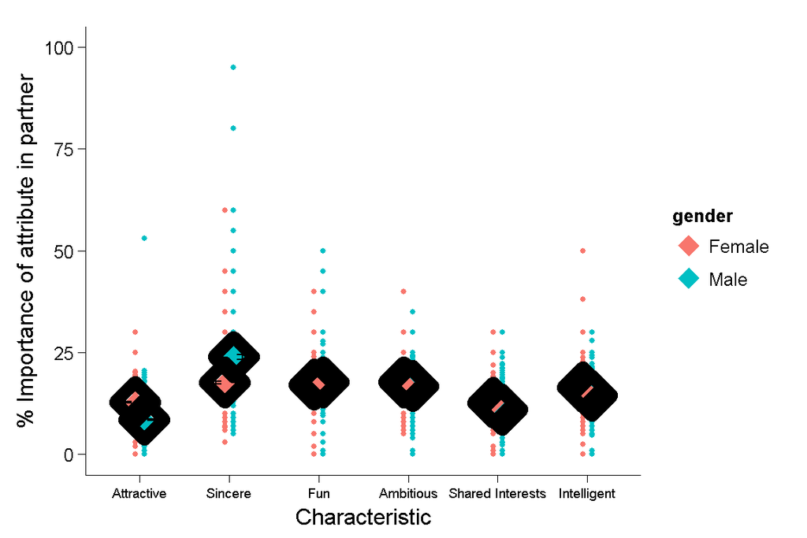

### Question 2: How much do you enjoy your date depending on your initial preferences and actual race of the speed dating partner

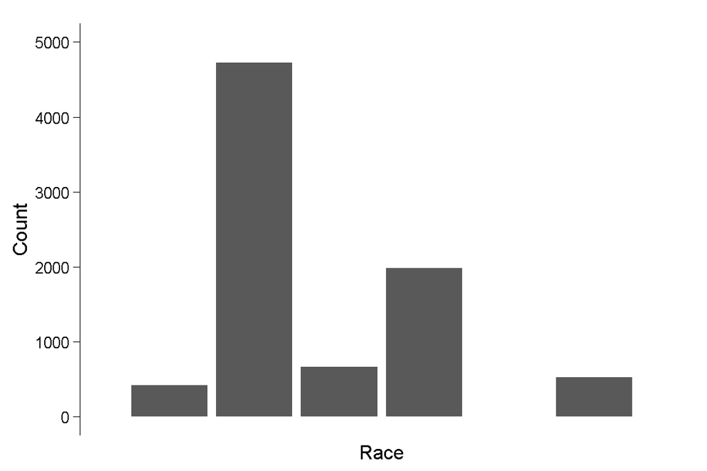

This histogram shows the self reported race of each participant in the speed dating experiment

```
 race race_o imprace        V1 equal
```

1: 4 2 2 5.892857 FALSE 2: 4 4 2 5.500000 TRUE 3: 4 3 2 6.000000 FALSE 4: 2 2 2 6.415825 TRUE 5: 2 4 2 6.073427 FALSE —  
203: 1 6 4 10.000000 FALSE 204: 3 4 8 1.142857 FALSE 205: 3 2 8 1.692308 FALSE 206: 3 6 8 1.000000 FALSE 207: 3 1 8 6.000000 FALSE

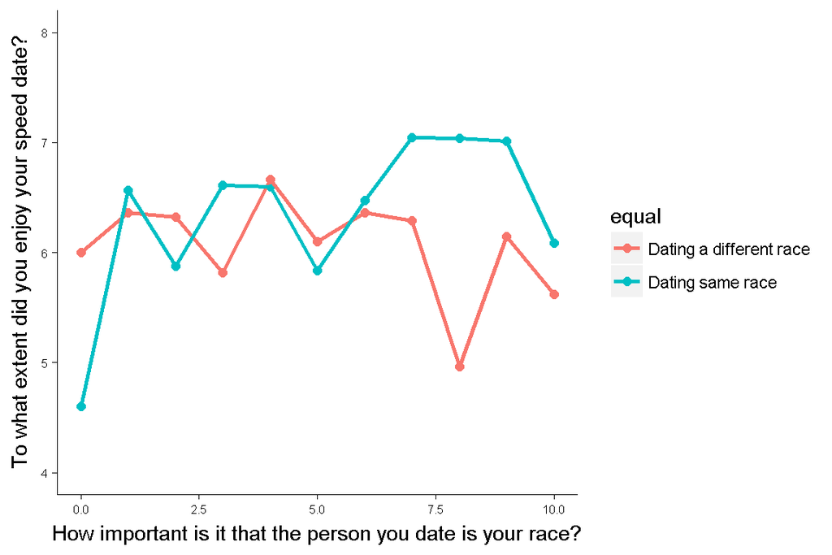

Key findings  
• For people with moderate preferences on the race of date (scores 1-6) there is no significant difference in satisfaction from date regardless if they date same or different race  
• For people with extreme preferences on date race, the fact of impacts significantly the satisfaction  
- People with high preference on dating same race (score 7-10) enjoy dating person from same race much more  
- People with very low preference on dating same race (score 0) enjoy dating people from different race much more

### Question 3: How much do you enjoy your date depending on if your date is the same race as you?

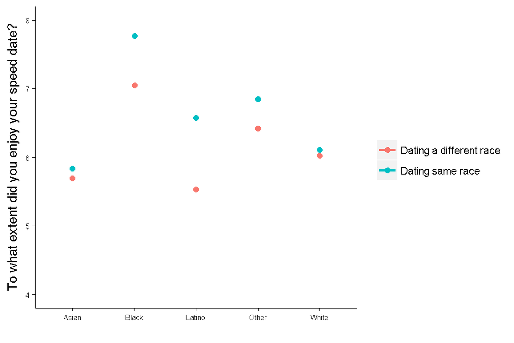

Key findings  
• There was a significant difference in satisfaction from speed dating between races  
- Maximum satisfaction from those that self report having Black heritage  
- Minimum satisfactiob from those that self report having Asian heritage  
• All races prefer dating people from the same race, but the race of the date significantly impacts satisfaction for some races and has limited impact on others  
- Practical indifference in dating from the same or different race in those that self report having White or Asian heritage  
- Significantly favour dating the same race in those that self report having Black or Latino heritage

### Question 4: How much do you enjoy your date depending on your race and race of the speed dating partner

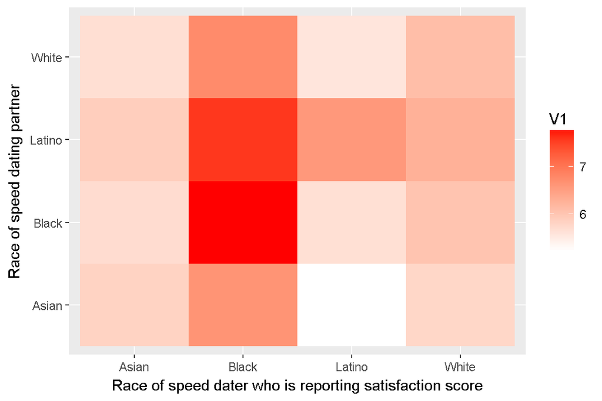